# Multiple Linear Regression

Skills Quiz

# Questions

## Summary

### Questions

##### Q1

Linear Models - Plotting, Equations and Summary Interpretation

##### Q2

Asumptions of Linear Regression

##### Q3

Perform linear regression test.

## Q1

##### 1.1

As explained in the help file (?SaratogaHouses), the SaratogaHouses data set contains data about many houses from Saratoga County, New York in the year 2006. Suppose a family is in search of a home that was 1) newly constructed and that has 2) three bedrooms. Suppose further that they are trying to decide how big of a livingArea they can afford and whether or not the price of the home is significantly impacted by adding a fireplace to their “dream home” wish list.

```r
# 1.1
palette(c("grey","firebrick"))

SH2 <- filter(SaratogaHouses, bedrooms == 3,  newConstruction=="Yes") %>%
  mutate(fireplace = ifelse(fireplaces > 0, 1,0))

plot(price ~ livingArea,
     data = SH2,
     col = as.factor(fireplace),
     main = "Saratoga Houses - Ideal Home",
     xlab = "Living Area",
     ylab = "Price",
     pch = 16)


legend("topleft",
       legend = c("No Fireplace","Fireplace"),
       col = c("grey","firebrick"),
       pch = 16,
       bty = "n")

mylm <- lm(price ~ livingArea + fireplace + livingArea:fireplace, data = SH2)
summary(mylm) %>% pander()
```

|  | Estimate | Std. Error | t value | Pr(>\|t\|) |
| --- | --- | --- | --- | --- |
| **(Intercept)** | -12290 | 59660 | -0.206 | 0.8392 |
| **livingArea** | 103.1 | 32.43 | 3.178 | 0.005499 |
| **fireplace** | -116723 | 74519 | -1.566 | 0.1357 |
| **livingArea:fireplace** | 74.75 | 37.94 | 1.97 | 0.06535 |

Fitting linear model: price ~ livingArea + fireplace + livingArea:fireplace

| Observations | Residual Std. Error | $R^2$ | Adjusted $R^2$ |
| --- | --- | --- | --- |
| 21 | 27707 | 0.8955 | 0.8771 |

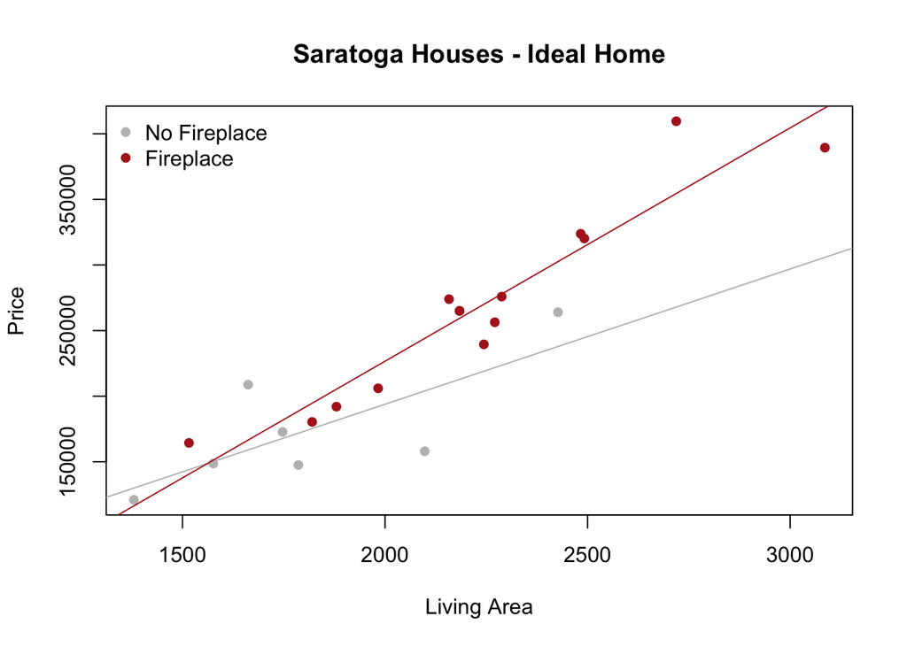

```r
abline(mylm$coefficients["(Intercept)"],
       mylm$coefficients["livingArea"], col=palette()[1])

abline(mylm$coefficients["(Intercept)"] + mylm$coefficients["fireplace"],
       mylm$coefficients["livingArea"] + mylm$coefficients["livingArea:fireplace"], col=palette()[2])
```

##### 1.2

Let’s diagnose the appropriateness of using a linear model for the data.

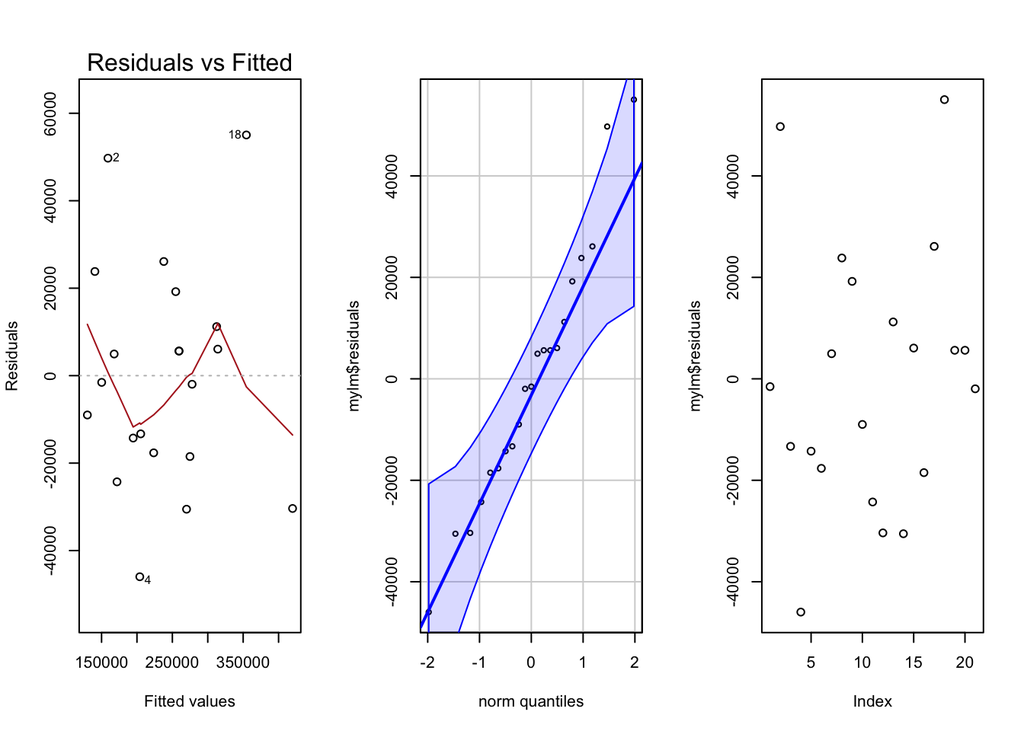

```r
# 1.2
par(mfrow=c(1,3))

plot(mylm, which=1)
qqPlot(mylm$residuals, id=FALSE)
plot(mylm$residuals)
```

## Q2

##### 2.1

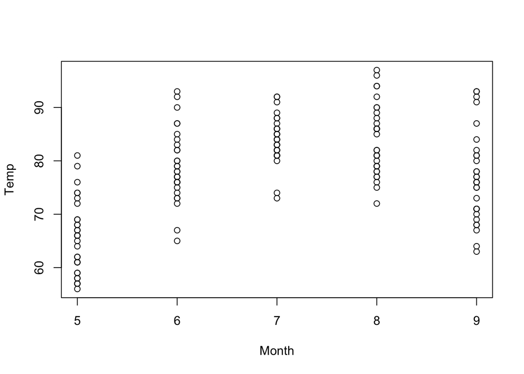

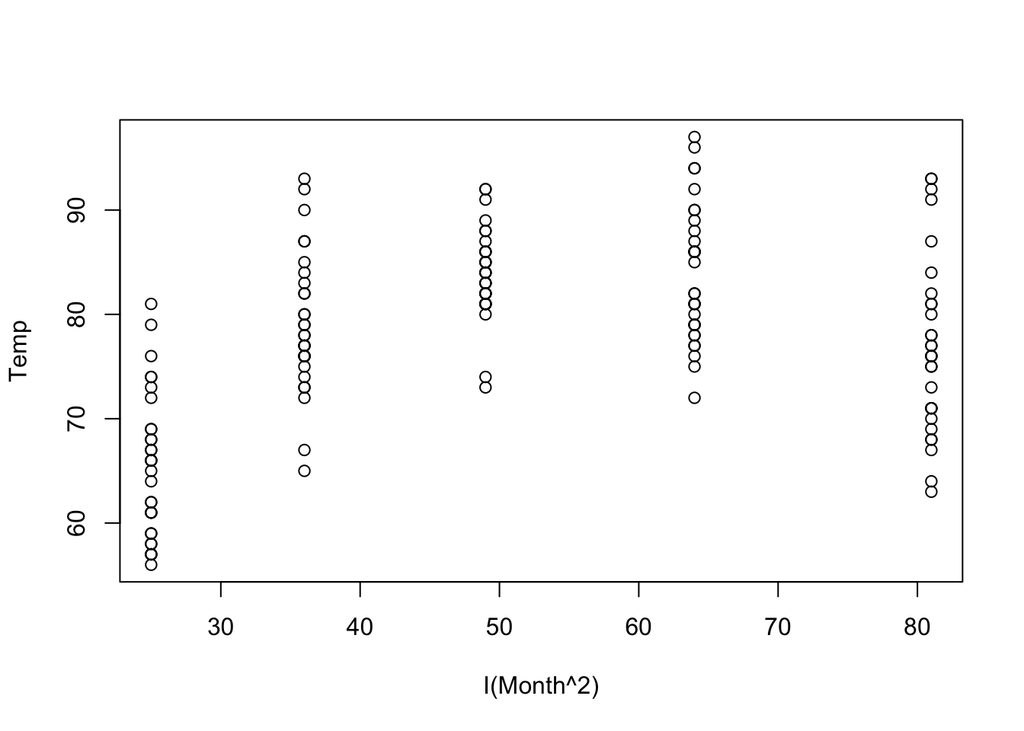

```r
# 2.1
aq <- airquality

plot(Temp ~ Month + I(Month^2), data = aq)
```

```r
mylm <- lm(Temp ~ Month + I(Month^2), data = aq)
summary(mylm) %>% pander()
```

|  | Estimate | Std. Error | t value | Pr(>\|t\|) |
| --- | --- | --- | --- | --- |
| **(Intercept)** | -95.73 | 15.24 | -6.281 | 3.458e-09 |
| **Month** | 48.72 | 4.489 | 10.85 | 1.29e-20 |
| **I(Month^2)** | -3.283 | 0.3199 | -10.26 | 4.737e-19 |

Fitting linear model: Temp ~ Month + I(Month^2)

| Observations | Residual Std. Error | $R^2$ | Adjusted $R^2$ |
| --- | --- | --- | --- |
| 153 | 6.624 | 0.5166 | 0.5102 |

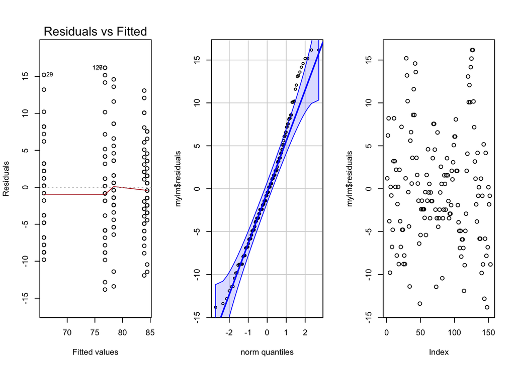

```r
par(mfrow=c(1,3))

plot(mylm, which=1)
qqPlot(mylm$residuals, id=FALSE)
plot(mylm$residuals)
```

```r
par(mfrow = c(1,1)) #This resets your plotting window for future plots.
```

##### 2.2

```r
# 2.2
july_fourth = 7.129032

mylm <- lm(Temp ~ Month + I(Month^2), data = aq)
summary(mylm) %>% pander()
```

|  | Estimate | Std. Error | t value | Pr(>\|t\|) |
| --- | --- | --- | --- | --- |
| **(Intercept)** | -95.73 | 15.24 | -6.281 | 3.458e-09 |
| **Month** | 48.72 | 4.489 | 10.85 | 1.29e-20 |
| **I(Month^2)** | -3.283 | 0.3199 | -10.26 | 4.737e-19 |

Fitting linear model: Temp ~ Month + I(Month^2)

| Observations | Residual Std. Error | $R^2$ | Adjusted $R^2$ |
| --- | --- | --- | --- |
| 153 | 6.624 | 0.5166 | 0.5102 |

```r
# Estimate  Std. Error  t value Pr(>|t|)
# (Intercept)   -95.73  15.24   -6.281  3.458e-09
# Month 48.72   4.489   10.85   1.29e-20
# I(Month^2)    -3.283  0.3199  -10.26  4.737e-19

temp_july_fourth <-
  (mylm$coefficients["(Intercept)"]) +
  (mylm$coefficients["Month"] * july_fourth) +
  (july_fourth^2) * mylm$coefficients["I(Month^2)"]

# The average temperature on July 4th.
temp_july_fourth
```

```
## (Intercept)
##    84.74588
```

##### 2.3

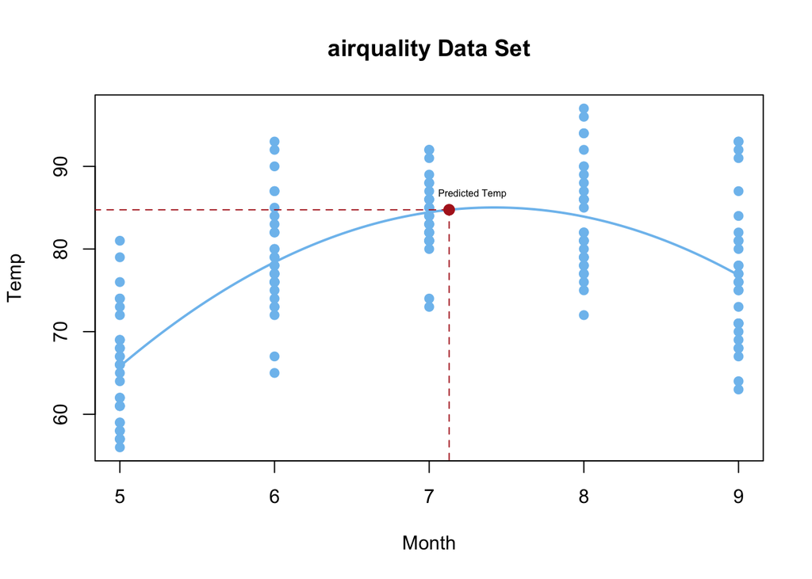

```r
# 2.3
plot(Temp ~ Month, data = aq, col="skyblue2", pch = 19, main = "airquality Data Set")

curve(predict(mylm, data.frame(Month = x)), add=TRUE, col="skyblue2", lwd=2)

lines(c(july_fourth, july_fourth), c(0, temp_july_fourth), lty=2, col="firebrick")

lines(c(0, july_fourth), c(temp_july_fourth, temp_july_fourth), lty=2, col="firebrick")

points(july_fourth, temp_july_fourth, cex=1.2, col="firebrick", pch = 19)

text(july_fourth + .15, temp_july_fourth + .2 , "Predicted Temp", cex=0.5, pos=3)
```

##### 2.4

This formula is how we identify the vertex of the quadratic line. It’s not always meaningful but sometimes it is.

$$\frac{-\beta_1}{2\cdot\beta_2}$$

The x value of the vertex is:

```r
# 2.4
vertex_x <- -(mylm$coefficients["Month"]) / (2 * mylm$coefficients["I(Month^2)"])
vertex_x
```

```
##    Month
## 7.420204
```

##### 2.5

The y value of the vertex is:

```r
# 2.5
vertex_y <-
  (mylm$coefficients["(Intercept)"]) +
  (mylm$coefficients["Month"] * vertex_x +
  (vertex_x^2) * mylm$coefficients["I(Month^2)"])
vertex_y
```

```
## (Intercept)
##     85.0242
```

## Q3

##### 3.1

```r
# 3.1
```

##### 3.2

```r
# 3.2
```

##### 3.3

```r
# 3.3
```

##### 3.4

```r
# 3.4
```

##### 3.5

```r
# 3.5
```

##### 3.6

```r
# 3.6
```

##### 3.7

```r
# 3.7
```

##### 3.8

```r
# 3.8
```

##### 3.9

```r
# 3.9
```

##### 3.10

```r
# 3.10
```

## Q4

##### 4.1

```r
# 4.1
?faithful
```

##### 4.2

Perform a simple linear regression to determine if the expected waiting time to the next eruption can be modeled by the length of the previous eruption.

```r
# 4.2
mylm <- lm(waiting ~ eruptions, data = faithful)
summary(mylm) %>% pander()
```

|  | Estimate | Std. Error | t value | Pr(>\|t\|) |
| --- | --- | --- | --- | --- |
| **(Intercept)** | 33.47 | 1.155 | 28.99 | 7.136e-85 |
| **eruptions** | 10.73 | 0.3148 | 34.09 | 8.13e-100 |

Fitting linear model: waiting ~ eruptions

| Observations | Residual Std. Error | $R^2$ | Adjusted $R^2$ |
| --- | --- | --- | --- |
| 272 | 5.914 | 0.8115 | 0.8108 |

##### 4.3

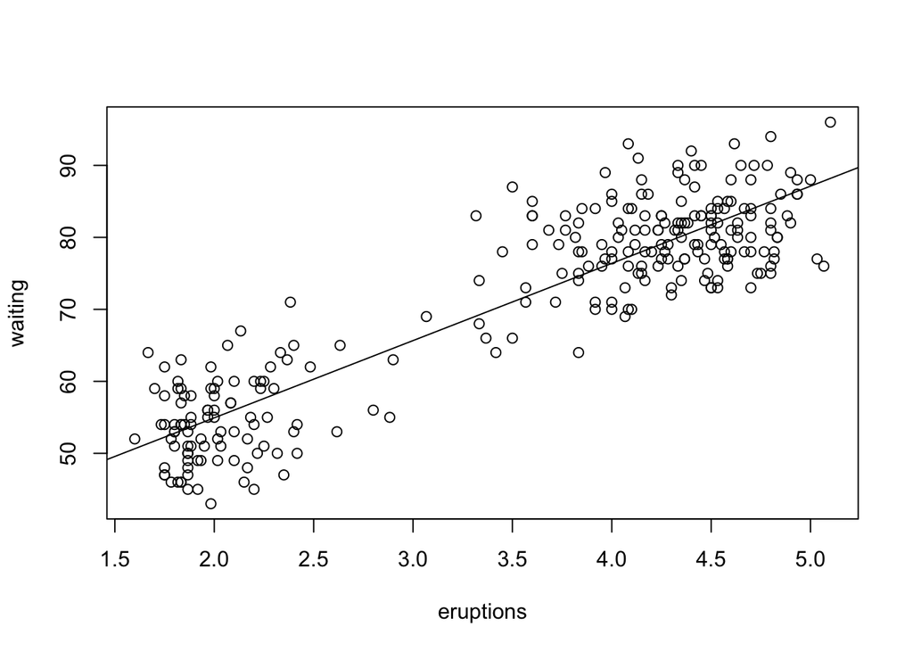

```r
# 4.3
plot(waiting ~ eruptions, data = faithful)
abline(mylm)
```

##### 4.4

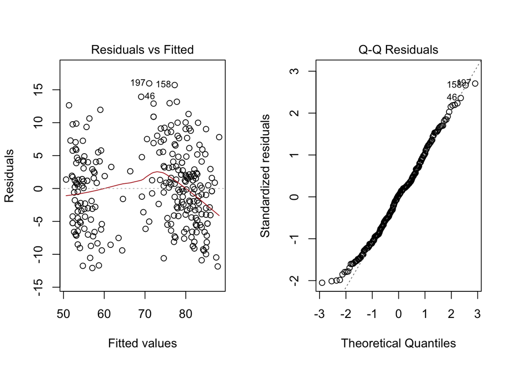

```r
# 4.4
par(mfrow=c(1,2))
plot(mylm, which=1:2)
```

```r
par(mfrow = c(1,1)) #This resets your plotting window for future plots.
```

##### 4.5

If the erruption is 3.5 minutes we would expect the visitor to wait in minutes about:

```r
# 4.5
yint <-  33.47
increase <- 10.73
t = 3.5

wait_time <- yint + (t * increase)
wait_time
```

```
## [1] 71.025
```

##### 4.6

```r
# 4.6
```

##### 4.7

```r
# 4.7
```

##### 4.8

```r
# 4.8
```

##### 4.9

```r
# 4.9
```

##### 4.10

```r
# 4.10
```